# Assignment 3

Author

anonymous

# 1 General information

**Setup**

*This block will only be visible in your HTML output, but will be hidden when rendering to PDF for the submission.* **Make sure that this does not get displayed in the PDF!**

This is the template for assignment 3. You can download the qmd-files ([full](https://raw.githubusercontent.com/avehtari/BDA_course_Aalto/gh-pages/assignments/template3.qmd), [simple](https://raw.githubusercontent.com/avehtari/BDA_course_Aalto/gh-pages/assignments/simple_template3.qmd)) or copy the code from this rendered document after clicking on `</> Code` in the top right corner.

**Please replace the instructions in this template by your own text, explaining what you are doing in each exercise.**

The following will set-up [`markmyassignment`](https://github.com/MansMeg/markmyassignment) to check your functions at the end of the notebook:

```r
if(!require(markmyassignment)){
    install.packages("markmyassignment")
    library(markmyassignment)
}
assignment_path = paste("https://github.com/avehtari/BDA_course_Aalto/",
"blob/master/assignments/tests/assignment3.yml", sep="")
set_assignment(assignment_path)
```

```
Assignment set:
assignment3: Bayesian Data Analysis: Assignment 3
The assignment contain the following (6) tasks:
- mu_point_est
- mu_interval
- mu_pred_interval
- mu_pred_point_est
- posterior_odds_ratio_point_est
- posterior_odds_ratio_interval
```

The following installs and loads the `aaltobda` package:

```r
if(!require(aaltobda)){
    install.packages("remotes")
    remotes::install_github("avehtari/BDA_course_Aalto", subdir = "rpackage", upgrade="never")
    library(aaltobda)
}
```

The following installs and loads the [`latex2exp` package](https://github.com/stefano-meschiari/latex2exp), which allows us to use LaTeX in plots:

```r
if(!require(latex2exp)){
    install.packages("latex2exp")
    library(latex2exp)
}
```

**Showcase: Setting up advanced packages (`posterior` and `ggdist`)**

*This block will only be visible in your HTML output, but will be hidden when rendering to PDF for the submission.* **Make sure that this does not get displayed in the PDF!**

*This block showcases advanced tools, which you will be allowed and expected to use after this assignment.* **For now, you should solve the assignment without the tools showcased herein.**

The following installs and loads the [`posterior` package](https://mc-stan.org/posterior/index.html), which allows us to use its [`rvar` Random Variable Datatype](https://mc-stan.org/posterior/articles/rvar.html):

```r
if(!require(posterior)){
    install.packages("posterior")
    library(posterior)
}
```

```
This is posterior version 1.2.0
```

The following installs and loads the [`ggdist` package](https://mjskay.github.io/ggdist/) for advanced plotting functions:

```r
if(!require(ggplot2)){
    install.packages("ggplot2")
    library(ggplot2)
}
ggplot2::theme_set(theme_minimal(base_size = 14))
if(!require(ggdist)){
    install.packages("ggdist")
    library(ggdist)
}
```

*This block showcases advanced tools, which you will be allowed and expected to use after this assignment.* **For now, you should solve the assignment without the tools showcased herein.**

# 2 Inference for normal mean and deviation (3 points)

**Loading the library and the data.**

```r
data("windshieldy1")
# The data are now stored in the variable `windshieldy1`.
# The below displays the data:
windshieldy1
```

```
[1] 13.357 14.928 14.896 15.297 14.820 12.067 14.824 13.865 17.447
```

The below data is **only for the tests**, you need to change to the full data `windshieldy1` when reporting your results.

```r
windshieldy_test <- c(13.357, 14.928, 14.896, 14.820)
```

## 2.1 (a)

$$Likelihood: p(y| \mu, \sigma^2) \propto \sigma^{-n} \exp{(-\frac{1}{2\sigma^2} \sum_{i=1}^n(y_i - \mu)^2)}$$
$$prior: p(\mu, \sigma^2) \propto \frac{1}{\sigma^2}$$
$$posterior: p(\mu, \sigma^2 | y) \propto \sigma^{-n-2} \exp{(-\frac{1}{2\sigma^2} \sum_{i=1}^n(y_i - \mu)^2)}$$

## 2.2 (b)

Under non informative prior the marginal posterior for normalized $\mu$ has distribution ~$t_{n_1}$  
The unknown $\mu$ lies with 95% confidence between 13.47808 15.74436, and the mean of it’s distribution is 14.61122

**Keep the below name and format for the functions to work with `markmyassignment`:**

```r
# Useful functions: mean(), length(), sqrt(), sum()
# and qtnew(), dtnew() (from aaltobda)


mu_point_est <- function(data) {
    # Do computation here, and return as below.
    # This is the correct return value for the test data provided above.
    y_mean = mean(data)
    n = length(data)
    sd = sqrt(sum((data - y_mean)**2)/(n-1))

    mean_estimate= qtnew(0.5, df=n-1, mean=y_mean, scale=(sd/sqrt(n)))
    mean_estimate

}
mu_interval <- function(data, prob = 0.95) {
    # Do computation here, and return as below.
    # This is the correct return value for the test data provided above.
    y_mean = mean(data)
    n = length(data)
    sd = sqrt(sum((data - y_mean)**2)/(n-1))

    low_estimate= qtnew((1-prob)/2, df=n-1, y_mean, (sd/sqrt(n)))

    high_estimate= qtnew(1-(1-prob)/2, df=n-1,  y_mean, (sd/sqrt(n)))
    c(low_estimate, high_estimate)
    # c(13.3, 15.7)

}
# mu_point_est(windshieldy1)
# mu_interval(windshieldy1)
```

You can plot the density as below if you implement `mu_pdf` to compute the PDF of the posterior $p(\mu|y)$ of the average hardness $\mu$.

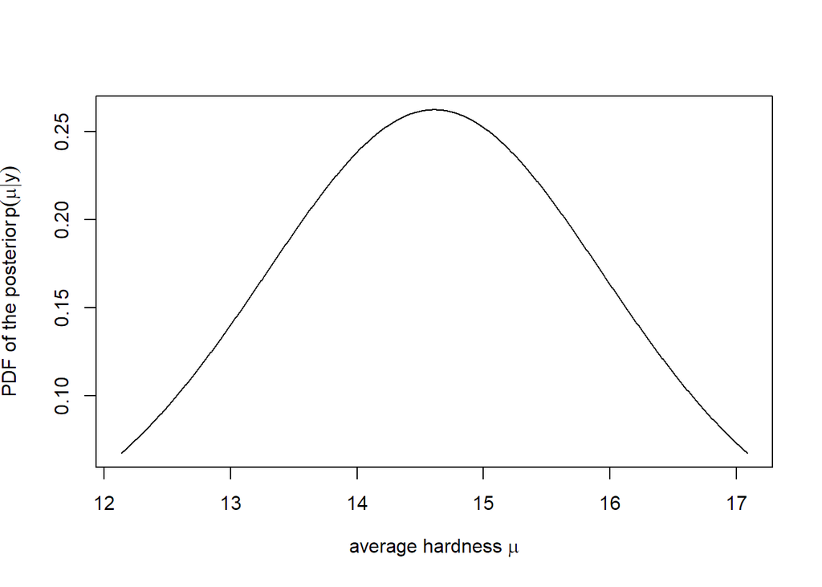

Figure 1: PDF of the posterior $p(\mu|y)$ of the average hardness $\mu$

```r
mu_pdf <- function(data, x){
    # Compute necessary parameters here.
    # These are the correct parameters for `windshieldy_test`
    # with the provided uninformative prior.
    location = mean(data)
    df = length(data)-1
    scale = sqrt(sum((data - location)**2)/df)
    # df = 3
    # location = 14.5
    # scale = 0.3817557
    # Use the computed parameters as below to compute the PDF:

    dtnew(x, df, location, scale)
}

x_interval = mu_interval(windshieldy1, .999)
lower_x = x_interval[1]
upper_x = x_interval[2]
x = seq(lower_x, upper_x, length.out=1000)
plot(
    x, mu_pdf(windshieldy1, x), type="l",
    xlab=TeX(r'(average hardness $\mu$)'),
    ylab=TeX(r'(PDF of the posterior $p(\mu|y)$)')
)
```

## 2.3 (c)

The posterior predictive distribution for a future observation given the uninformative prior and the likelihood following a normal distribution is distributed as $\tilde{y} \sim t_{n-1} \text{with location = }\bar y \text{ and scale = } (1+\frac{1}{n}^{1/2})*s$

**Keep the below name and format for the functions to work with `markmyassignment`:**

```r
# Useful functions: mean(), length(), sqrt(), sum()
# and qtnew(), dtnew() (from aaltobda)

mu_pred_point_est <- function(data) {
    # Do computation here, and return as below.
    # This is the correct return value for the test data provided above.
    y_mean = mean(data)
    n = length(data)
    sd = sqrt(sum((data - y_mean)**2)/(n-1))

    mean_estimate= qtnew(0.5, df=n-1, mean=y_mean, scale=sd*(1+1/n)^(1/2))
    mean_estimate
    # 14.5

}
mu_pred_interval <- function(data, prob = 0.95) {
    # Do computation here, and return as below.
    # This is the correct return value for the test data provided above.
    y_mean = mean(data)
    n = length(data)
    sd = sqrt(sum((data - y_mean)**2)/(n-1))

    low_estimate= qtnew((1-prob)/2, df=n-1, mean=y_mean,scale=sd*(1+1/n)^(1/2))

    high_estimate= qtnew(1-(1-prob)/2, df=n-1,  mean=y_mean, scale=sd*(1+1/n)^(1/2))
    c(low_estimate, high_estimate)
    # c(11.8, 17.2)

}

mu_pred_point_est(windshieldy_test)
```

```
[1] 14.50025
```

```r
mu_pred_interval(windshieldy_test)
```

```
[1] 11.78361 17.21689
```

You can plot the density as below if you implement `mu_pred_pdf` to compute the PDF of the posterior predictive $p(\tilde{y}|y)$ of a new hardness observation $\tilde{y}$.

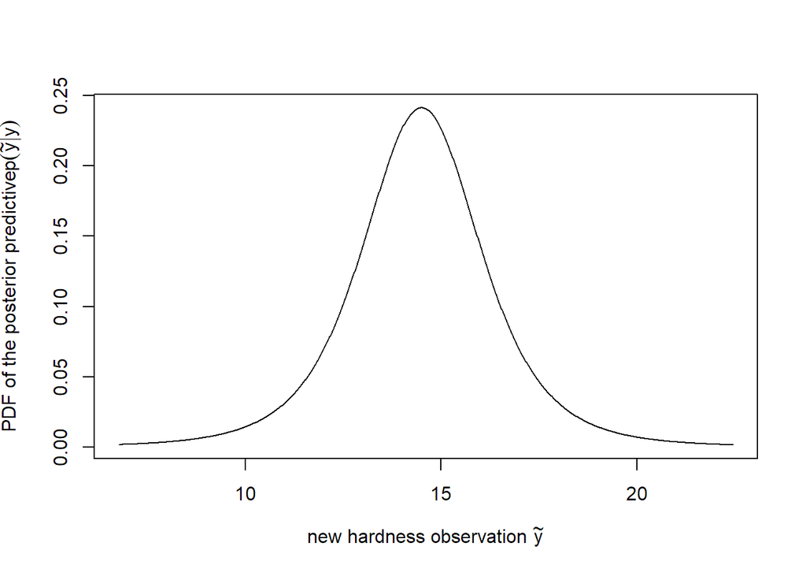

Figure 2: PDF of the posterior predictive $p(\tilde{y}|y)$ of a new hardness observation $\tilde{y}$

```r
mu_pred_pdf <- function(data, x){
    # Compute necessary parameters here.
    # These are the correct parameters for `windshieldy_test`
    # with the provided uninformative prior.
    df = 4
    location = 14.5
    scale = 1.553903
    # Use the computed parameters as below to compute the PDF:

    dtnew(x, df, location, scale)
}

x_interval = mu_pred_interval(windshieldy1, .999)
lower_x = x_interval[1]
upper_x = x_interval[2]
x = seq(lower_x, upper_x, length.out=1000)
plot(
    x, mu_pred_pdf(windshieldy1, x), type="l",
    xlab=TeX(r'(new hardness observation $\tilde{y}$)'),
    ylab=TeX(r'(PDF of the posterior predictive $p(\tilde{y}|y)$)')
)
```

# 3 Inference for the difference between proportions (3 points)

## 3.1 (a)

Using independent distributions.
P0
$$\text{likelihood:} p(y|p_0) \propto p_0^{39} * (1-p_0)^{635}$$
$$\text{prior:} p(p_0) \propto p_0^{\alpha -1}*(1-p_0)^{\beta - 1}$$
$$\text{posterior:} p(p_0|y) \propto Beta(\alpha + 39, \beta + 674 - 39)$$

P1
$$\text{likelihood:} p(y|p_1) \propto p_1^{22} * (1-p_1)^{658}$$
$$\text{prior:} p(p_1) \propto p_1^{\alpha -1}*(1-p_1)^{\beta - 1}$$
$$\text{posterior:} p(p_1|y) \propto Beta(\alpha + 22, \beta + 680 - 22)$$

## 3.2 (b)

Assuming uninformative uniform prior distributions for p0 and p1 (control and treatment) we find that that the mean odds ratio is 0.57 and that the 0.95 credible interval is [0.32, 0.92]. The probability is 0.95 that the true treatment effect is in the interval [0.32, 0.92]. This means that with high probability the patients in treatment group are less likely to die.

The below data is **only for the tests**:

```r
set.seed(4711)
no_samples = 1000
p0 = rbeta(no_samples, 5, 95)
p1 = rbeta(no_samples, 10, 90)
```

**Keep the below name and format for the functions to work with `markmyassignment`:**

```r
# Actual data
set.seed(4711)
no_samples = 1000
p0_data = rbeta(no_samples, 40, 636)
p1_data = rbeta(no_samples, 23, 659 )
```

```r
# Useful function: mean(), quantile()

posterior_odds_ratio_point_est <- function(p0, p1) {
    odds_ratio = (p1 / (1-p1)) / (p0 / (1-p0))
    mean_odds_ratio = mean(odds_ratio)
    mean_odds_ratio
    # Do computation here, and return as below.
    # This is the correct return value for the test data provided above.
    # 2.650172

}
posterior_odds_ratio_interval <- function(p0, p1, prob = 0.95) {
    odds_ratio = (p1 / (1-p1)) / (p0 / (1-p0))

    left_tail = (1-prob)/2
    right_tail =  1 - left_tail

    c(quantile(odds_ratio, probs=c(left_tail, right_tail)))
    # Do computation here, and return as below.
    # This is the correct return value for the test data provided above.
    # c(0.6796942,7.3015964)

}

posterior_odds_ratio_point_est(p0_data, p1_data) # 0.57
```

```
[1] 0.5710218
```

```r
posterior_odds_ratio_interval(p0_data, p1_data) # 0.3221829 0.9220926
```

```
     2.5%     97.5%
0.3221829 0.9220926
```

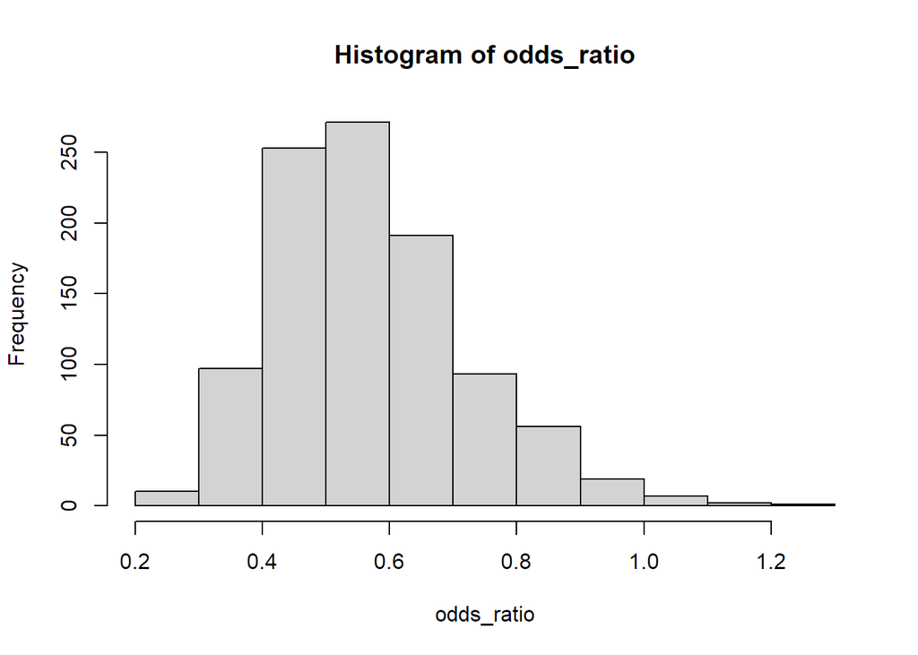

```r
library(dplyr)
library(tidyr)
odds_ratio = (p1_data / (1-p1_data)) / (p0_data / (1-p0_data))
hist(odds_ratio)
```

```r
# data = data.frame(group = c(replicate(no_samples, "control"), replicate(no_samples, "treatment")))
# data = data %>% mutate(parameter = c(p0_data, p1_data))
#
# ggplot(data= data) +
#   geom_histogram(aes(parameter, color=group), fill="white", alpha=0.2, position='identity')
```

**Showcase: advanced tools (`posterior`’s `rvar`, `ggdist`’s `stat_dotsinterval`)**

*This block will only be visible in your HTML output, but will be hidden when rendering to PDF for the submission.* **Make sure that this does not get displayed in the PDF!**

*This block showcases advanced tools, which you will be allowed and expected to use after this assignment.* **For now, you should solve the assignment without the tools showcased herein.**

The `posterior` package’s random variable datatype `rvar` is a [“sample-based representation of random variables”](https://mc-stan.org/posterior/articles/rvar.html#:~:text=sample%2Dbased%20representation%20of%20random%20variables) which makes handling of random samples such as the ones contained in the above variables `p0` and `p1` easier. [By default, it prints as the mean and standard deviation of the samples](https://mc-stan.org/posterior/articles/rvar.html#:~:text=The%20default%20display%20of%20an%20rvar%20shows%20the%20mean%20and%20standard%20deviation%20of%20each%20element%20of%20the%20array.), **such that `rvar(p0)` prints as 0.05 ± 0.021 and `rvar(p1)` prints as 0.1 ± 0.029**.

The datatype is “designed to […] be able to be used inside `data.frame()`s and `tibble()`s, and to be used with distribution visualizations in the ggdist package.” The code below sets up an [R `data.frame()`](https://www.rdocumentation.org/packages/base/versions/3.6.2/topics/data.frame) with the samples in `p0` and `p1` wrapped in an `rvar`, and uses that data frame to visualize the samples using [`ggdist`](https://mjskay.github.io/ggdist/index.html), an R package building on [`ggplot2`](https://ggplot2.tidyverse.org/) and [“designed for both frequentist and Bayesian uncertainty visualization”](https://mjskay.github.io/ggdist/index.html#:~:text=designed%20for%20both%20frequentist%20and%20Bayesian%20uncertainty%20visualization).

The below plot, Figure 3 uses `ggdist`’s [`stat_dotsinterval()`](https://mjskay.github.io/ggdist/articles/dotsinterval.html), which by default visualizes

- an `rvar`’s median and central 66% and 95% intervals using a black dot and lines of varying thicknesses as when using `ggdist`’s [`stat_pointinterval()`](https://mjskay.github.io/ggdist/reference/stat_pointinterval.html#examples) and
- an `rvar`’s samples using grey dots as when using `ggdist`’s [`stat_dots()`](https://mjskay.github.io/ggdist/reference/stat_dots.html#examples):

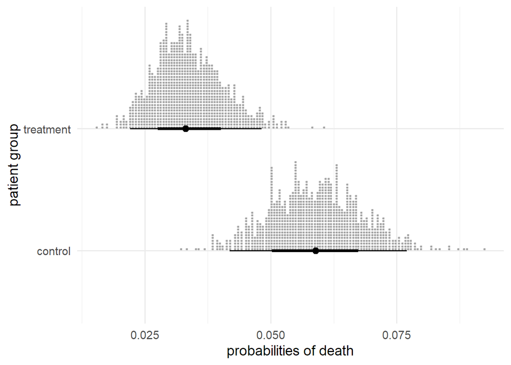

Figure 3: Probabilities of death for the two patient groups.

```r
r0 = rvar(p0_data)
r1 = rvar(p1_data)
ggplot(data.frame(
    rv_name=c("control", "treatment"), rv=c(r0, r1)
)) +
    aes(xdist=rv, y=rv_name) +
    labs(x="probabilities of death", y="patient group") +
    stat_dotsinterval()
```

`rvar`s make it easy to compute functions of random variables, such as

- differences, e.g. $p_0 - p_1$: `r0 - r1` computes an `rvar` which prints as 0.025 ± 0.011, indicating the **sample mean** and the **sample standard deviation** of the difference of the probabilities of death,
- products, e.g. $p_0 \, p_1$: `r0 * r1` computes an `rvar` which prints as 0.002 ± 0.00052 which in this case has no great interpretation, or
- the odds ratios needed in task 3.b).

Below, in Figure 4, we compute the odds ratios using the `rvar`s and visualize its median, central intervals and samples, as above in Figure 3:

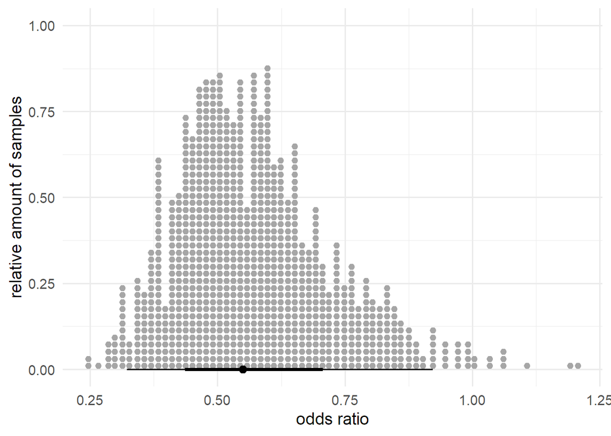

Figure 4: Odds ratios of the two patient groups.

```r
rodds_ratio = (r1/(1-r1))/(r0/(1-r0))
ggplot(data.frame(
    rv=c(rodds_ratio)
)) +
    aes(xdist=rv) +
    labs(x="odds ratio", y="relative amount of samples") +
    stat_dotsinterval()
```

You can use Figure 4 to visually check whether the answers you computed for 3.b) make sense.

*This block showcases advanced tools, which you will be allowed and expected to use after this assignment.* **For now, you should solve the assignment without the tools showcased herein.**

## 3.3 (c)

Comparing the uniform prior with a beta distribution prior with parameters 50/100 (roughly 50% of deaths in each group) we see that the posterior odds ratio are shifted towards the 1, meaning that data shows a probable effect of treatment but observations are not enough to totally dominate the prior and have an effect as strong as with the uniform prior.

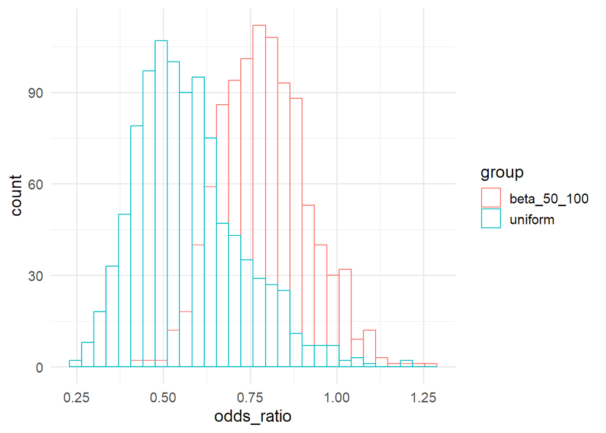

```r
# Uniform prior
set.seed(4711)
no_samples = 1000
p0_data = rbeta(no_samples, 40, 636)
p1_data = rbeta(no_samples, 23, 659 )
odds_ratio_uniform = (p1_data / (1-p1_data)) / (p0_data / (1-p0_data))

# 50/100
p0_data_2 = rbeta(no_samples, 89, 685)
p1_data_2 = rbeta(no_samples, 72, 708 )
odds_ratio_50_100 = (p1_data_2 / (1-p1_data_2)) / (p0_data_2 / (1-p0_data_2))




dataplot = data.frame(group = c(replicate(no_samples, "uniform"), replicate(no_samples, "beta_50_100")))
dataplot = dataplot %>% mutate(odds_ratio = c(odds_ratio_uniform,odds_ratio_50_100)
                       )
ggplot(data=dataplot) +
  geom_histogram(aes(x=odds_ratio, colour=group),  fill="white", alpha=0.2, position='identity')
```

```r
# data = data %>% pivot_longer(!x, names_to = "odds_ratio", values_to = "density")
```

# 4 Inference for the difference between normal means (3 points)

**Loading the library and the data.**

```r
data("windshieldy2")
# The new data are now stored in the variable `windshieldy2`.
# The below displays the first few rows of the new data:
head(windshieldy2)
```

```
[1] 15.980 14.206 16.011 17.250 15.993 15.722
```

## 4.1 (a)

windshieldy1
$$Likelihood: p(y| \mu_1, \sigma_1^2) \propto \sigma_1^{-n_1} \exp{(-\frac{1}{2\sigma_1^2} \sum_{i=1}^n(y_{1i} - \mu_1)^2)}$$
$$prior: p(\mu_1, \sigma_1^2) \propto \frac{1}{\sigma_1^2}$$
$$posterior: p(\mu_1, \sigma_1^2 | y_1) \propto \sigma_1^{-n_1-2} \exp{(-\frac{1}{2\sigma_1^2} \sum_{i=1}^n(y_{1i} - \mu_1)^2)}$$

Same for windshieldy2 but with it’s corresponding subscript.

## 4.2 (b)

**Write your answers and code here!**

```r
mu_diff_point_est <- function(data1, data2) {
    # Do computation here, and return as below.
    # This is the correct return value for the test data provided above.
    y1_mean = mean(data1)
    n_1 = length(data1)
    sd_1 = sqrt(sum((data1 - y1_mean)**2)/(n_1-1))
    posterior1 = rtnew(1000, df=n_1-1, mean=y1_mean, scale=(sd_1/sqrt(n_1)))

    y2_mean = mean(data2)
    n_2 = length(data2)
    sd_2 = sqrt(sum((data2 - y2_mean)**2)/(n_2-1))
    posterior2 = rtnew(1000, df=n_2-1, mean=y2_mean, scale=(sd_2/sqrt(n_2)))

    mu_diff = posterior1 - posterior2
    mean(mu_diff)
}

mu_diff_interval <- function(data1, data2, prob=0.95) {
    # Do computation here, and return as below.
    # This is the correct return value for the test data provided above.
    y1_mean = mean(data1)
    n_1 = length(data1)
    sd_1 = sqrt(sum((data1 - y1_mean)**2)/(n_1-1))
    posterior1 = rtnew(1000, df=n_1-1, mean=y1_mean, scale=(sd_1/sqrt(n_1)))

    y2_mean = mean(data2)
    n_2 = length(data2)
    sd_2 = sqrt(sum((data2 - y2_mean)**2)/(n_2-1))
    posterior2 = rtnew(1000, df=n_2-1, mean=y2_mean, scale=(sd_2/sqrt(n_2)))

    mu_diff = posterior1 - posterior2

    low = (1-prob)/2
    high = 1 -low
    c(quantile(mu_diff, c(low, high)))
}

plot_difference <- function(data1, data2){
    y1_mean = mean(data1)
    n_1 = length(data1)
    sd_1 = sqrt(sum((data1 - y1_mean)**2)/(n_1-1))
    posterior1 = rtnew(1000, df=n_1-1, mean=y1_mean, scale=(sd_1/sqrt(n_1)))

    y2_mean = mean(data2)
    n_2 = length(data2)
    sd_2 = sqrt(sum((data2 - y2_mean)**2)/(n_2-1))
    posterior2 = rtnew(1000, df=n_2-1, mean=y2_mean, scale=(sd_2/sqrt(n_2)))

    mu_diff = posterior1 - posterior2
    hist(mu_diff)
}

# Useful functions: mean(), length(), sqrt(), sum(),
# rtnew() (from aaltobda), quantile() and hist().
```

```r
mu_diff_point_est(windshieldy1, windshieldy2)
```

```
[1] -1.21092
```

```r
mu_diff_interval(windshieldy1, windshieldy2)
```

```
      2.5%      97.5%
-2.4306047  0.1050471
```

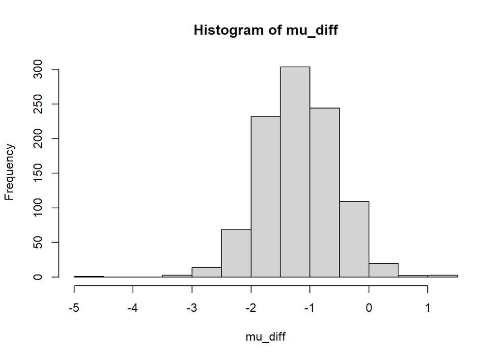

```r
plot_difference(windshieldy1, windshieldy2)
```

Since the hardness is a continuous variable I think it’s not possible to determine if the means are exactly the same, we could get a density for the mean difference = 0 but that’s it.

What we can do is to calculate the probability of a small interval containing 0. The probability the mu difference is between -0.05 and 0.05 is around 0.7%

```r
mu_zero_interval <- function(data1, data2, sides=0.05) {
    # Do computation here, and return as below.
    # This is the correct return value for the test data provided above.
    y1_mean = mean(data1)
    n_1 = length(data1)
    sd_1 = sqrt(sum((data1 - y1_mean)**2)/(n_1-1))
    posterior1 = rtnew(1000, df=n_1-1, mean=y1_mean, scale=(sd_1/sqrt(n_1)))

    y2_mean = mean(data2)
    n_2 = length(data2)
    sd_2 = sqrt(sum((data2 - y2_mean)**2)/(n_2-1))
    posterior2 = rtnew(1000, df=n_2-1, mean=y2_mean, scale=(sd_2/sqrt(n_2)))

    mu_diff = posterior1 - posterior2

    low = 0 - sides
    high = 0  + sides
    inrange = sum(mu_diff > low & mu_diff < high)
    n  = length(mu_diff)
    inrange/n
}
```

```r
mu_zero_interval(windshieldy1, windshieldy2)
```

```
[1] 0.007
```

**markmyassignment**

*This block will only be visible in your HTML output, but will be hidden when rendering to PDF for the submission.* **Make sure that this does not get displayed in the PDF!**

The following will check the functions for which `markmyassignment` has been set up:

```r
mark_my_assignment()
```

```
v | F W S  OK | Context

/ |         0 | task-1-subtask-1-tests
/ |         0 | mu_point_est()
v |         4 | mu_point_est()

/ |         0 | task-2-subtask-1-tests
/ |         0 | mu_interval()
v |         5 | mu_interval()

/ |         0 | task-3-subtask-1-tests
/ |         0 | mu_pred_interval()
v |         5 | mu_pred_interval()

/ |         0 | task-4-subtask-1-tests
/ |         0 | mu_pred_point_est()
v |         4 | mu_pred_point_est()

/ |         0 | task-5-subtask-1-tests
/ |         0 | posterior_odds_ratio_point_est()
- |         5 | posterior_odds_ratio_point_est()
v |         6 | posterior_odds_ratio_point_est() [0.1s]

/ |         0 | task-6-subtask-1-tests
/ |         0 | posterior_odds_ratio_interval()
| |         7 | posterior_odds_ratio_interval()
v |         8 | posterior_odds_ratio_interval() [0.1s]

== Results =====================================================================
Duration: 0.4 s

[ FAIL 0 | WARN 0 | SKIP 0 | PASS 32 ]
Good work!
```